# Example_6_Adaptive_POD_with_step_geometry_and_boundary_layers

## Example 6 - Using Adaptive POD With a Step Geometry and Boundary Layers

In this example, we cover the use of the adaptive POD with geometry loaded in from a $\texttt{.step}$ file description.

## Structure of Boundary Layers

Following the advice in Tutorial 7, we assign 2 layers of prismatic elements of thickness $\tau$ and $2\tau$, with $\tau$ being the normalised skin depth. We also specify that we desire a homogeneous cube, so the material for the boundary layers matches the material for the cube interior. These settings can easily be updated in the OCC file.

Be aware that using large numbers of prismatic elements dramatically increases the number of degrees of freedom (and potentially the matrix condition number) and will typically take significantly longer to run than the using a pure tetrahedral mesh with the same settings.

## Usage

We begin by setting the root directory

```python
import os
# Please edit this line to provide the to the root directory of your copy of MPT-Calculator
Your_Path=r"/home/pdl11/Coding/MPT_calculator/Sept2025/MPT-Calculator"#'C:\Users\James\Desktop\MPT-Calculator'

os.chdir(Your_Path)
print(os.getcwd())

from main import main
import numpy as np
```

```
/home/pdl11/Coding/MPT_calculator/Sept2025/MPT-Calculator
```

and specify the sweep parameters we are interested in. As before, $\alpha$ has been specified directly in the OCC file.

```
Updated alpha from OCC file. Alpha=0.001
OCC_step_cube_prism.geo
[0, 1] 2 ['air', 'cube']
Mesh Contains Prisms? True
N Prisms: 2736, N Tets: 23345
[0, 1] 2 ['air', 'cube']
```

[output not shown]

```
 solved theta0 problems
```

```
manually closed pool
 Iteration 1
 SVD complete
 Number of retained modes = 7
 Number of retained modes = 7
 Built K, Q, E, and Ger model
manually closed pool
 reduced order systems solved
 Computing Errors
Adding Snapshots at omega = [10000000.          2424462.01708233]
```

```
manually closed pool
 solved theta1 problems
 Weighted Error Estimate = 9967.87448583693, Iteration 1
 Iteration 2
 SVD complete
 Number of retained modes = 9
 Number of retained modes = 9
 Built K, Q, E, and Ger model
manually closed pool
 reduced order systems solved
 Computing Errors
The interval between 1.000e+07 and 1.000e+08 rad/s doesn't seem to be decreasing at the snapshots. Skipping for refinement.
Adding Snapshots at omega = [ 203091.76209047 1193776.64171444]
```

```
manually closed pool
 solved theta1 problems
 Weighted Error Estimate = 750.4450309850382, Iteration 2
 Iteration 3
 SVD complete
 Number of retained modes = 11
 Number of retained modes = 11
 Built K, Q, E, and Ger model
manually closed pool
 reduced order systems solved
 Computing Errors
The interval between 1.000e+07 and 1.000e+08 rad/s doesn't seem to be decreasing at the snapshots. Skipping for refinement.
Adding Snapshots at omega = [4923882.63170674  100000.        ]
```

```
manually closed pool
 solved theta1 problems
 Weighted Error Estimate = 10.926629647872788, Iteration 3
 Iteration 4
 SVD complete
 Number of retained modes = 13
 Number of retained modes = 13
 Built K, Q, E, and Ger model
manually closed pool
 reduced order systems solved
 Computing Errors
The interval between 4.924e+06 and 6.813e+06 rad/s doesn't seem to be decreasing at the snapshots. Skipping for refinement.
The interval between 6.813e+06 and 1.000e+07 rad/s doesn't seem to be decreasing at the snapshots. Skipping for refinement.
The interval between 1.000e+07 and 1.000e+08 rad/s doesn't seem to be decreasing at the snapshots. Skipping for refinement.
Adding Snapshots at omega = [1701254.27985259  837677.64006829]
```

```
manually closed pool
 solved theta1 problems
 Weighted Error Estimate = 3.2610321006737273, Iteration 4
 Iteration 5
 SVD complete
 Number of retained modes = 15
 Number of retained modes = 15
 Built K, Q, E, and Ger model
manually closed pool
 reduced order systems solved
 Computing Errors
The interval between 8.377e+05 and 1.194e+06 rad/s doesn't seem to be decreasing at the snapshots. Skipping for refinement.
The interval between 1.194e+06 and 1.701e+06 rad/s doesn't seem to be decreasing at the snapshots. Skipping for refinement.
The interval between 1.701e+06 and 2.424e+06 rad/s doesn't seem to be decreasing at the snapshots. Skipping for refinement.
The interval between 2.424e+06 and 4.924e+06 rad/s doesn't seem to be decreasing at the snapshots. Skipping for refinement.
The interval between 4.924e+06 and 6.813e+06 rad/s doesn't seem to be decreasing at the snapshots. Skipping for refinement.
The interval between 6.813e+06 and 1.000e+07 rad/s doesn't seem to be decreasing at the snapshots. Skipping for refinement.
The interval between 1.000e+07 and 1.000e+08 rad/s doesn't seem to be decreasing at the snapshots. Skipping for refinement.
Adding Snapshots at omega = [17012.54279853 49238.82631707]
```

```
manually closed pool
 solved theta1 problems
 Weighted Error Estimate = 3.262675709085776, Iteration 5
 Iteration 6
 SVD complete
 Number of retained modes = 17
 Number of retained modes = 17
 Built K, Q, E, and Ger model
manually closed pool
 reduced order systems solved
 Computing Errors
The interval between 4.642e+05 and 8.377e+05 rad/s doesn't seem to be decreasing at the snapshots. Skipping for refinement.
The interval between 8.377e+05 and 1.194e+06 rad/s doesn't seem to be decreasing at the snapshots. Skipping for refinement.
The interval between 1.194e+06 and 1.701e+06 rad/s doesn't seem to be decreasing at the snapshots. Skipping for refinement.
The interval between 1.701e+06 and 2.424e+06 rad/s doesn't seem to be decreasing at the snapshots. Skipping for refinement.
The interval between 2.424e+06 and 4.924e+06 rad/s doesn't seem to be decreasing at the snapshots. Skipping for refinement.
The interval between 4.924e+06 and 6.813e+06 rad/s doesn't seem to be decreasing at the snapshots. Skipping for refinement.
The interval between 6.813e+06 and 1.000e+07 rad/s doesn't seem to be decreasing at the snapshots. Skipping for refinement.
The interval between 1.000e+07 and 1.000e+08 rad/s doesn't seem to be decreasing at the snapshots. Skipping for refinement.
Adding Snapshots at omega = [142510.2670303  289426.61247168]
```

```
manually closed pool
 solved theta1 problems
 Weighted Error Estimate = 3.2638243977872277, Iteration 6
 Iteration 7
 SVD complete
 Number of retained modes = 18
 Number of retained modes = 18
 creating reduced order model
```

```
 Built K, Q, E, and Ger model
manually closed pool
 reduced order systems solved
 Computing Errors
The interval between 3.162e+04 and 4.924e+04 rad/s doesn't seem to be decreasing at the snapshots. Skipping for refinement.
The interval between 4.924e+04 and 1.000e+05 rad/s doesn't seem to be decreasing at the snapshots. Skipping for refinement.
The interval between 1.000e+05 and 1.425e+05 rad/s doesn't seem to be decreasing at the snapshots. Skipping for refinement.
The interval between 1.425e+05 and 2.031e+05 rad/s doesn't seem to be decreasing at the snapshots. Skipping for refinement.
The interval between 2.031e+05 and 2.894e+05 rad/s doesn't seem to be decreasing at the snapshots. Skipping for refinement.
The interval between 2.894e+05 and 4.642e+05 rad/s doesn't seem to be decreasing at the snapshots. Skipping for refinement.
The interval between 4.642e+05 and 8.377e+05 rad/s doesn't seem to be decreasing at the snapshots. Skipping for refinement.
The interval between 8.377e+05 and 1.194e+06 rad/s doesn't seem to be decreasing at the snapshots. Skipping for refinement.
The interval between 1.194e+06 and 1.701e+06 rad/s doesn't seem to be decreasing at the snapshots. Skipping for refinement.
The interval between 1.701e+06 and 2.424e+06 rad/s doesn't seem to be decreasing at the snapshots. Skipping for refinement.
The interval between 2.424e+06 and 4.924e+06 rad/s doesn't seem to be decreasing at the snapshots. Skipping for refinement.
The interval between 4.924e+06 and 6.813e+06 rad/s doesn't seem to be decreasing at the snapshots. Skipping for refinement.
The interval between 6.813e+06 and 1.000e+07 rad/s doesn't seem to be decreasing at the snapshots. Skipping for refinement.
The interval between 1.000e+07 and 1.000e+08 rad/s doesn't seem to be decreasing at the snapshots. Skipping for refinement.
Adding Snapshots at omega = [24244.62017082  8376.77640068]
```

```
manually closed pool
 solved theta1 problems
 Weighted Error Estimate = 3.2643880612762675, Iteration 7
 Iteration 8
 SVD complete
 Number of retained modes = 18
 Number of retained modes = 18
 Built K, Q, E, and Ger model
manually closed pool
 reduced order systems solved
 Computing Errors
The interval between 1.000e+01 and 1.468e+02 rad/s doesn't seem to be decreasing at the snapshots. Skipping for refinement.
The interval between 1.468e+02 and 2.154e+03 rad/s doesn't seem to be decreasing at the snapshots. Skipping for refinement.
The interval between 1.701e+04 and 2.424e+04 rad/s doesn't seem to be decreasing at the snapshots. Skipping for refinement.
The interval between 2.424e+04 and 3.162e+04 rad/s doesn't seem to be decreasing at the snapshots. Skipping for refinement.
The interval between 3.162e+04 and 4.924e+04 rad/s doesn't seem to be decreasing at the snapshots. Skipping for refinement.
The interval between 1.000e+05 and 1.425e+05 rad/s doesn't seem to be decreasing at the snapshots. Skipping for refinement.
The interval between 1.425e+05 and 2.031e+05 rad/s doesn't seem to be decreasing at the snapshots. Skipping for refinement.
The interval between 2.031e+05 and 2.894e+05 rad/s doesn't seem to be decreasing at the snapshots. Skipping for refinement.
The interval between 2.894e+05 and 4.642e+05 rad/s doesn't seem to be decreasing at the snapshots. Skipping for refinement.
The interval between 4.642e+05 and 8.377e+05 rad/s doesn't seem to be decreasing at the snapshots. Skipping for refinement.
The interval between 8.377e+05 and 1.194e+06 rad/s doesn't seem to be decreasing at the snapshots. Skipping for refinement.
The interval between 1.194e+06 and 1.701e+06 rad/s doesn't seem to be decreasing at the snapshots. Skipping for refinement.
The interval between 1.701e+06 and 2.424e+06 rad/s doesn't seem to be decreasing at the snapshots. Skipping for refinement.
The interval between 2.424e+06 and 4.924e+06 rad/s doesn't seem to be decreasing at the snapshots. Skipping for refinement.
The interval between 4.924e+06 and 6.813e+06 rad/s doesn't seem to be decreasing at the snapshots. Skipping for refinement.
The interval between 6.813e+06 and 1.000e+07 rad/s doesn't seem to be decreasing at the snapshots. Skipping for refinement.
The interval between 1.000e+07 and 1.000e+08 rad/s doesn't seem to be decreasing at the snapshots. Skipping for refinement.
Adding Snapshots at omega = [ 2894.26612472 70170.38286704]
```

```
manually closed pool
 solved theta1 problems
 Weighted Error Estimate = 3.2641839044599257, Iteration 8
 Iteration 9
 SVD complete
 Number of retained modes = 18
 Number of retained modes = 18
 Built K, Q, E, and Ger model
manually closed pool
 reduced order systems solved
 Computing Errors
The interval between 1.000e+01 and 1.468e+02 rad/s doesn't seem to be decreasing at the snapshots. Skipping for refinement.
The interval between 1.468e+02 and 2.154e+03 rad/s doesn't seem to be decreasing at the snapshots. Skipping for refinement.
The interval between 2.154e+03 and 2.894e+03 rad/s doesn't seem to be decreasing at the snapshots. Skipping for refinement.
The interval between 2.894e+03 and 8.377e+03 rad/s doesn't seem to be decreasing at the snapshots. Skipping for refinement.
The interval between 1.701e+04 and 2.424e+04 rad/s doesn't seem to be decreasing at the snapshots. Skipping for refinement.
The interval between 3.162e+04 and 4.924e+04 rad/s doesn't seem to be decreasing at the snapshots. Skipping for refinement.
The interval between 4.924e+04 and 7.017e+04 rad/s doesn't seem to be decreasing at the snapshots. Skipping for refinement.
The interval between 7.017e+04 and 1.000e+05 rad/s doesn't seem to be decreasing at the snapshots. Skipping for refinement.
The interval between 1.000e+05 and 1.425e+05 rad/s doesn't seem to be decreasing at the snapshots. Skipping for refinement.
The interval between 1.425e+05 and 2.031e+05 rad/s doesn't seem to be decreasing at the snapshots. Skipping for refinement.
The interval between 2.031e+05 and 2.894e+05 rad/s doesn't seem to be decreasing at the snapshots. Skipping for refinement.
The interval between 2.894e+05 and 4.642e+05 rad/s doesn't seem to be decreasing at the snapshots. Skipping for refinement.
The interval between 4.642e+05 and 8.377e+05 rad/s doesn't seem to be decreasing at the snapshots. Skipping for refinement.
The interval between 8.377e+05 and 1.194e+06 rad/s doesn't seem to be decreasing at the snapshots. Skipping for refinement.
The interval between 1.194e+06 and 1.701e+06 rad/s doesn't seem to be decreasing at the snapshots. Skipping for refinement.
The interval between 1.701e+06 and 2.424e+06 rad/s doesn't seem to be decreasing at the snapshots. Skipping for refinement.
The interval between 2.424e+06 and 4.924e+06 rad/s doesn't seem to be decreasing at the snapshots. Skipping for refinement.
The interval between 4.924e+06 and 6.813e+06 rad/s doesn't seem to be decreasing at the snapshots. Skipping for refinement.
The interval between 6.813e+06 and 1.000e+07 rad/s doesn't seem to be decreasing at the snapshots. Skipping for refinement.
The interval between 1.000e+07 and 1.000e+08 rad/s doesn't seem to be decreasing at the snapshots. Skipping for refinement.
Adding Snapshots at omega = [11937.76641714]
```

```
manually closed pool
 solved theta1 problems
 Weighted Error Estimate = 3.2640987027492327, Iteration 9
 Iteration 10
 SVD complete
 Number of retained modes = 18
 Number of retained modes = 18
 Built K, Q, E, and Ger model
manually closed pool
 reduced order systems solved
 Computing Errors
The interval between 1.000e+01 and 1.468e+02 rad/s doesn't seem to be decreasing at the snapshots. Skipping for refinement.
The interval between 1.468e+02 and 2.154e+03 rad/s doesn't seem to be decreasing at the snapshots. Skipping for refinement.
The interval between 2.154e+03 and 2.894e+03 rad/s doesn't seem to be decreasing at the snapshots. Skipping for refinement.
The interval between 2.894e+03 and 8.377e+03 rad/s doesn't seem to be decreasing at the snapshots. Skipping for refinement.
The interval between 1.194e+04 and 1.701e+04 rad/s doesn't seem to be decreasing at the snapshots. Skipping for refinement.
The interval between 1.701e+04 and 2.424e+04 rad/s doesn't seem to be decreasing at the snapshots. Skipping for refinement.
The interval between 3.162e+04 and 4.924e+04 rad/s doesn't seem to be decreasing at the snapshots. Skipping for refinement.
The interval between 4.924e+04 and 7.017e+04 rad/s doesn't seem to be decreasing at the snapshots. Skipping for refinement.
The interval between 7.017e+04 and 1.000e+05 rad/s doesn't seem to be decreasing at the snapshots. Skipping for refinement.
The interval between 1.000e+05 and 1.425e+05 rad/s doesn't seem to be decreasing at the snapshots. Skipping for refinement.
The interval between 1.425e+05 and 2.031e+05 rad/s doesn't seem to be decreasing at the snapshots. Skipping for refinement.
The interval between 2.031e+05 and 2.894e+05 rad/s doesn't seem to be decreasing at the snapshots. Skipping for refinement.
The interval between 2.894e+05 and 4.642e+05 rad/s doesn't seem to be decreasing at the snapshots. Skipping for refinement.
The interval between 4.642e+05 and 8.377e+05 rad/s doesn't seem to be decreasing at the snapshots. Skipping for refinement.
The interval between 8.377e+05 and 1.194e+06 rad/s doesn't seem to be decreasing at the snapshots. Skipping for refinement.
The interval between 1.194e+06 and 1.701e+06 rad/s doesn't seem to be decreasing at the snapshots. Skipping for refinement.
The interval between 1.701e+06 and 2.424e+06 rad/s doesn't seem to be decreasing at the snapshots. Skipping for refinement.
The interval between 2.424e+06 and 4.924e+06 rad/s doesn't seem to be decreasing at the snapshots. Skipping for refinement.
The interval between 4.924e+06 and 6.813e+06 rad/s doesn't seem to be decreasing at the snapshots. Skipping for refinement.
The interval between 6.813e+06 and 1.000e+07 rad/s doesn't seem to be decreasing at the snapshots. Skipping for refinement.
The interval between 1.000e+07 and 1.000e+08 rad/s doesn't seem to be decreasing at the snapshots. Skipping for refinement.
No suitable refinement found. Taking mean of largest 2 snapshots to use.
Adding Snapshots at omega = [55000000.]
```

```
manually closed pool
 solved theta1 problems
 Weighted Error Estimate = 3.2640892541362914, Iteration 10
```

[output not shown]

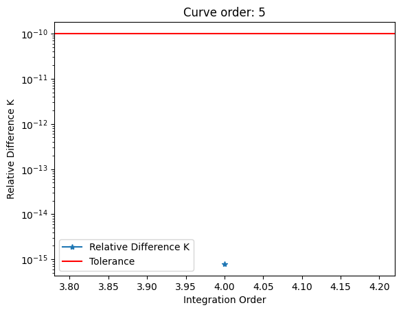

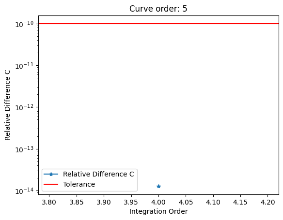

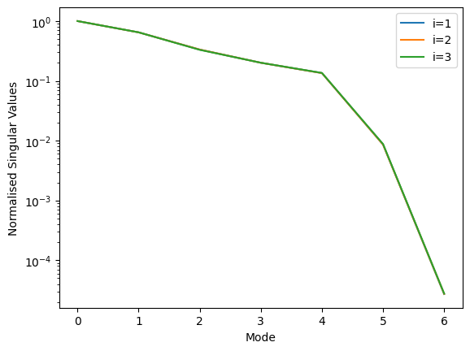

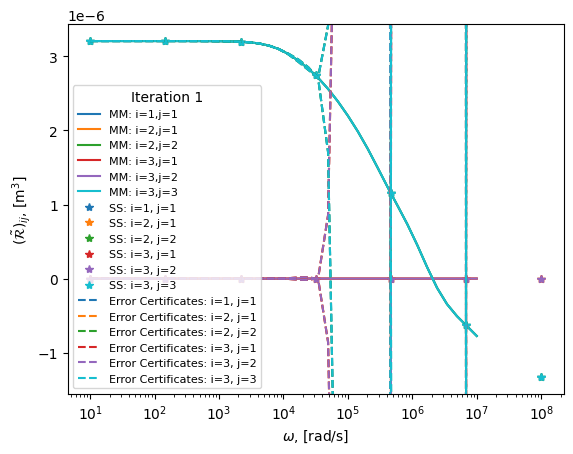

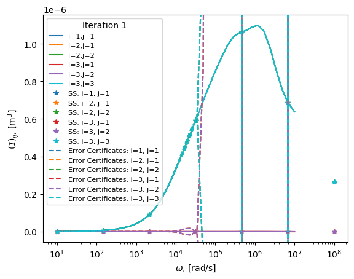

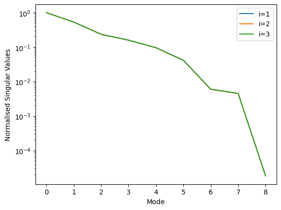

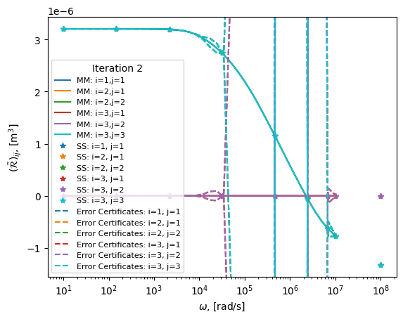

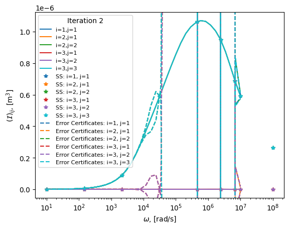

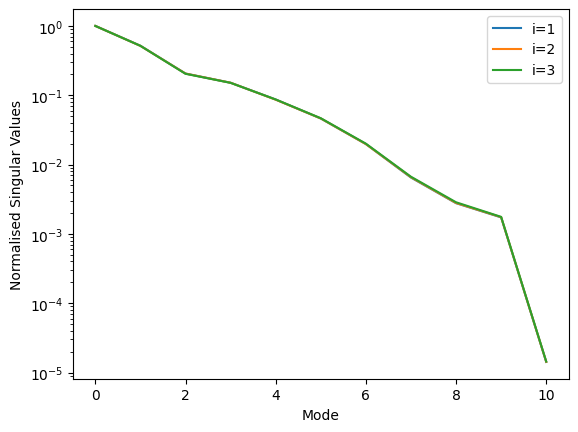

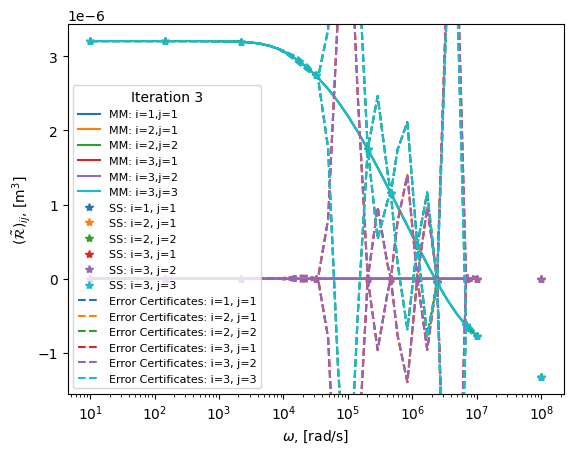

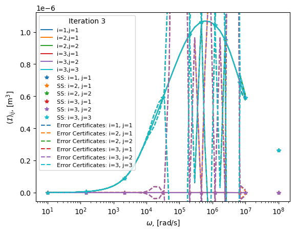

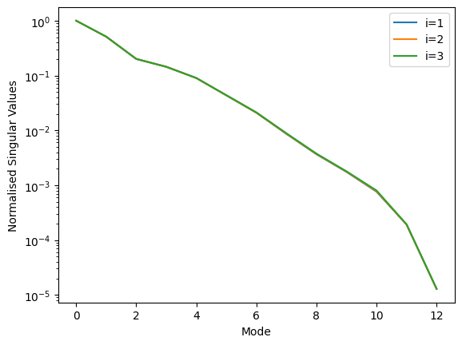

[21 more figures not shown]

```python
geometry = 'OCC_step_cube_prism.py'
start = 1
stop = 8
points = 40
order = 3
alpha = 1e-2
N_POD_Points = 7
mesh_coarseness = 'coarse'
frequency_array = np.logspace(1,7,points)

start_stop = (start, stop, points)

result = main(geometry=geometry, alpha=alpha, order=order, h=mesh_coarseness, start_stop=start_stop, frequency_array=frequency_array,
              use_OCC=True,use_POD=True, use_iterative_POD=True, N_POD_points=N_POD_Points, use_parallel=False)
```